# Practical Machine Learning Project

Gerald Herbosa

7/19/2020

Overview

The purpose of this project is to predict the manner of 6 participants where they perform some exercise which was recorded by gadgets like Jawbone Up, Nike FuelBand, and Fitbit. This is a requirement for the completion of Practical Machine Learning Course in Data Science Specialization. Algorithms utilized in this project was applied to the 20 test cases available in the test data given.

Loading and Cleaning of Data

```r
library(knitr)
library(rpart)
library(rpart.plot)
library(rattle)
library(caret)
library(randomForest)
library(corrplot)
# Reading the data
training <- read.csv('./pml-training.csv', header=T)
testing <- read.csv('./pml-testing.csv', header=T)

set.seed(1996)
part_train  <- createDataPartition(training$classe, p=0.7, list=FALSE)
set_train <- training[part_train, ]
set_test  <- training[-part_train, ]
dim(set_train)
```

```
## [1] 13737   160
```

```r
dim(set_test)
```

```
## [1] 5885  160
```

Each dataset contains 160 variables. Next step was to remove N/A values in dataset. Variables that are Near Zero variance (NZV) are removed and the ID variables.

```r
# NZV removal
nzv <- nearZeroVar(set_train)
set_train <- set_train[, -nzv]
set_test <- set_test[, -nzv]
dim(set_train)
```

```
## [1] 13737   106
```

```r
dim(set_test)
```

```
## [1] 5885  106
```

```r
# variables that are mostly NA to be remove
na <- sapply(set_train, function(x) mean(is.na(x))) > 0.95
set_train <- set_train[, na==FALSE]
set_test  <- set_test[, na==FALSE]
dim(set_train)
```

```
## [1] 13737    59
```

```r
dim(set_test)
```

```
## [1] 5885   59
```

```r
# ID variables which is columns 1 to 5 to be removed
set_train <- set_train[, -(1:5)]
set_test  <- set_test[, -(1:5)]
dim(set_train)
```

```
## [1] 13737    54
```

```r
dim(set_test)
```

```
## [1] 5885   54
```

Data Correlation

Analysis of variables and grasping the correlation is needed before proceeding with the modelling.

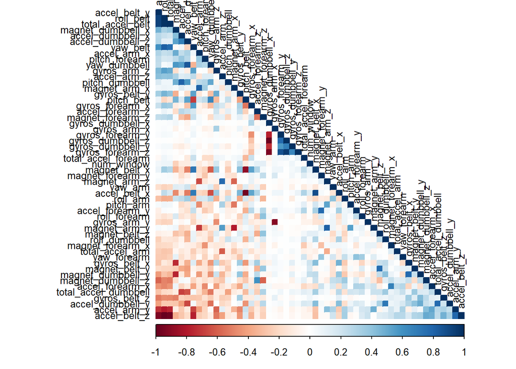

```r
matrix <- cor(set_train[, -54])
corrplot(matrix, order = "FPC", method = "color", type = "lower",
         tl.cex = 0.8, tl.col = rgb(0, 0, 0))
```

Building Model

Methods used are Random Forests, Decision Tree, and Generalized Boosted Model. These will be applied to the regression model in train data and the best method that gave a higher accuracy when applied to the test data will be utilized for the quiz. To visualize the data and compare accuracy, a confusion matrix is plotted for each.

```r
# fit model
rf_control <- trainControl(method="cv", number=3, verboseIter=FALSE)
randomforest_mod <- train(classe ~ ., data=set_train, method="rf", trControl=rf_control)
randomforest_mod$finalModel
```

```
##
## Call:
##  randomForest(x = x, y = y, mtry = param$mtry)
##                Type of random forest: classification
##                      Number of trees: 500
## No. of variables tried at each split: 27
##
##         OOB estimate of  error rate: 0.25%
## Confusion matrix:
##      A    B    C    D    E  class.error
## A 3904    1    0    0    1 0.0005120328
## B    6 2650    2    0    0 0.0030097818
## C    0    5 2390    1    0 0.0025041736
## D    0    0   11 2241    0 0.0048845471
## E    0    0    0    8 2517 0.0031683168
```

```r
# Test data prediction
rf_predict <- predict(randomforest_mod, newdata=set_test)
rf_conmatrix <- confusionMatrix(table(rf_predict, set_test$classe))
rf_conmatrix
```

```
## Confusion Matrix and Statistics
##
##
## rf_predict    A    B    C    D    E
##          A 1674    2    0    0    0
##          B    0 1137    1    0    0
##          C    0    0 1025    7    0
##          D    0    0    0  956    1
##          E    0    0    0    1 1081
##
## Overall Statistics
##
##                Accuracy : 0.998
##                  95% CI : (0.9964, 0.9989)
##     No Information Rate : 0.2845
##     P-Value [Acc > NIR] : < 2.2e-16
##
##                   Kappa : 0.9974
##
##  Mcnemar's Test P-Value : NA
##
## Statistics by Class:
##
##                      Class: A Class: B Class: C Class: D Class: E
## Sensitivity            1.0000   0.9982   0.9990   0.9917   0.9991
## Specificity            0.9995   0.9998   0.9986   0.9998   0.9998
## Pos Pred Value         0.9988   0.9991   0.9932   0.9990   0.9991
## Neg Pred Value         1.0000   0.9996   0.9998   0.9984   0.9998
## Prevalence             0.2845   0.1935   0.1743   0.1638   0.1839
## Detection Rate         0.2845   0.1932   0.1742   0.1624   0.1837
## Detection Prevalence   0.2848   0.1934   0.1754   0.1626   0.1839
## Balanced Accuracy      0.9998   0.9990   0.9988   0.9957   0.9994
```

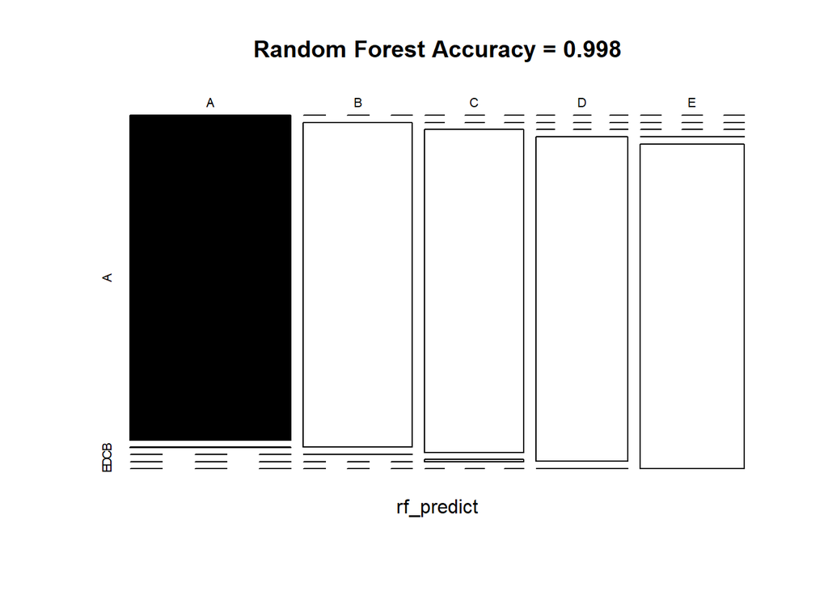

```r
plot(rf_conmatrix$table, col = rf_conmatrix$byClass,
     main = paste("Random Forest Accuracy =",
                  round(rf_conmatrix$overall['Accuracy'], 4)))
```

Decision Trees

[figure not shown]

```r
set.seed(1996)
decisiontree_modfit <- rpart(classe ~ ., data=set_train, method="class")
fancyRpartPlot(decisiontree_modfit)
```

```r
# Test data prediction
dectree_pred <- predict(decisiontree_modfit, newdata=set_test, type="class")
dectree_confusionmatrix <- confusionMatrix(table(dectree_pred, set_test$classe))
dectree_confusionmatrix
```

```
## Confusion Matrix and Statistics
##
##
## dectree_pred    A    B    C    D    E
##            A 1496  255   41   78   30
##            B   43  613   34   21   19
##            C   18   73  828  139   79
##            D   88  141   62  628  131
##            E   29   57   61   98  823
##
## Overall Statistics
##
##                Accuracy : 0.7456
##                  95% CI : (0.7343, 0.7567)
##     No Information Rate : 0.2845
##     P-Value [Acc > NIR] : < 2.2e-16
##
##                   Kappa : 0.6771
##
##  Mcnemar's Test P-Value : < 2.2e-16
##
## Statistics by Class:
##
##                      Class: A Class: B Class: C Class: D Class: E
## Sensitivity            0.8937   0.5382   0.8070   0.6515   0.7606
## Specificity            0.9041   0.9753   0.9364   0.9142   0.9490
## Pos Pred Value         0.7874   0.8397   0.7282   0.5981   0.7706
## Neg Pred Value         0.9553   0.8980   0.9583   0.9305   0.9462
## Prevalence             0.2845   0.1935   0.1743   0.1638   0.1839
## Detection Rate         0.2542   0.1042   0.1407   0.1067   0.1398
## Detection Prevalence   0.3229   0.1240   0.1932   0.1784   0.1815
## Balanced Accuracy      0.8989   0.7568   0.8717   0.7828   0.8548
```

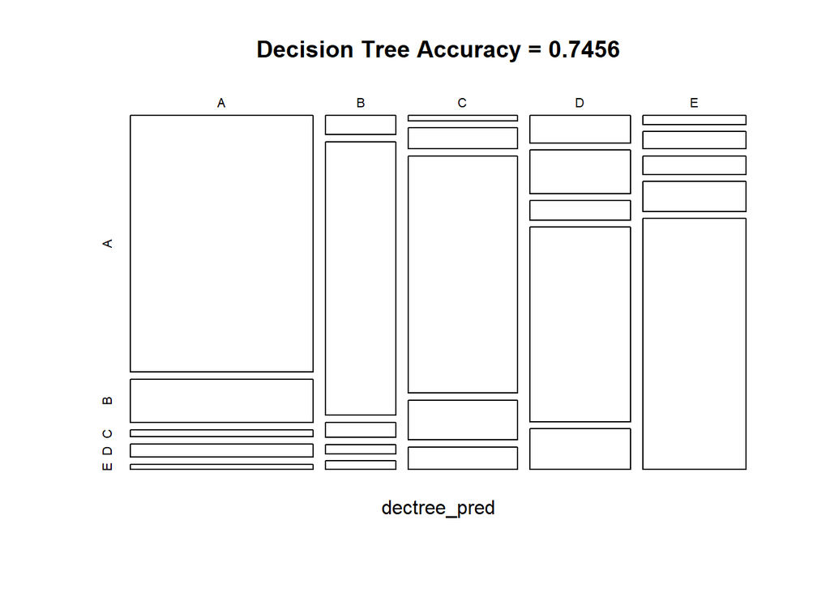

```r
# Results to be plotted
plot(dectree_confusionmatrix$table, col = dectree_confusionmatrix$byClass,
     main = paste("Decision Tree Accuracy =",
                  round(dectree_confusionmatrix$overall['Accuracy'], 4)))
```

Generalized Boosted Model

```r
# Fit Model
set.seed(1996)
GBM_con <- trainControl(method = "repeatedcv", number = 5, repeats = 1)
GBM_modelfit  <- train(classe ~ ., data=set_train, method = "gbm",
                    trControl = GBM_con, verbose = FALSE)
GBM_modelfit$finalModel
```

```
## A gradient boosted model with multinomial loss function.
## 150 iterations were performed.
## There were 53 predictors of which 53 had non-zero influence.
```

```r
# test data prediction
GBM_predict <- predict(GBM_modelfit, newdata=set_test)
GBM_cmatrix <- confusionMatrix(table(GBM_predict, set_test$classe))
GBM_cmatrix
```

```
## Confusion Matrix and Statistics
##
##
## GBM_predict    A    B    C    D    E
##           A 1669   12    0    0    0
##           B    5 1110    7    3    2
##           C    0   16 1014   10    3
##           D    0    1    4  950   12
##           E    0    0    1    1 1065
##
## Overall Statistics
##
##                Accuracy : 0.9869
##                  95% CI : (0.9837, 0.9897)
##     No Information Rate : 0.2845
##     P-Value [Acc > NIR] : < 2.2e-16
##
##                   Kappa : 0.9834
##
##  Mcnemar's Test P-Value : NA
##
## Statistics by Class:
##
##                      Class: A Class: B Class: C Class: D Class: E
## Sensitivity            0.9970   0.9745   0.9883   0.9855   0.9843
## Specificity            0.9972   0.9964   0.9940   0.9965   0.9996
## Pos Pred Value         0.9929   0.9849   0.9722   0.9824   0.9981
## Neg Pred Value         0.9988   0.9939   0.9975   0.9972   0.9965
## Prevalence             0.2845   0.1935   0.1743   0.1638   0.1839
## Detection Rate         0.2836   0.1886   0.1723   0.1614   0.1810
## Detection Prevalence   0.2856   0.1915   0.1772   0.1643   0.1813
## Balanced Accuracy      0.9971   0.9855   0.9912   0.9910   0.9919
```

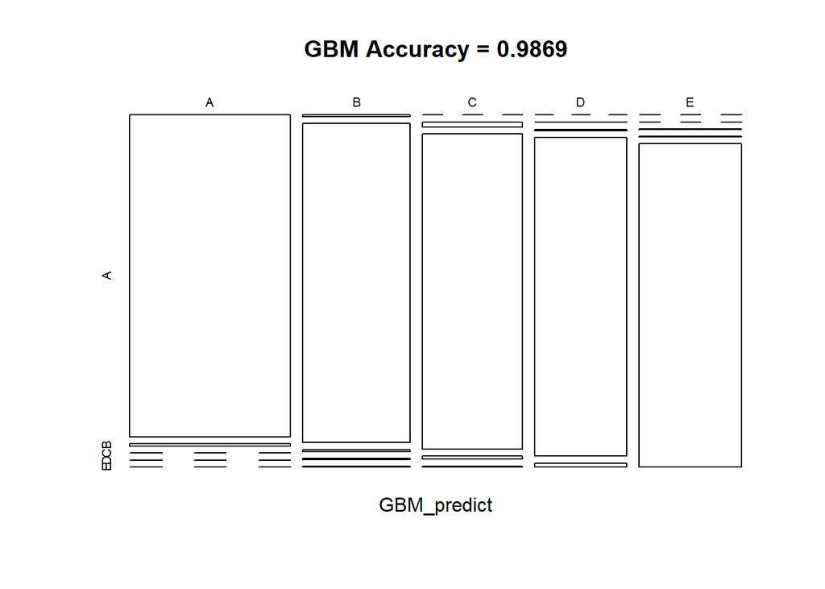

```r
# resulting matrix to be plotted
plot(GBM_cmatrix$table, col = GBM_cmatrix$byClass,
     main = paste("GBM Accuracy =", round(GBM_cmatrix$overall['Accuracy'], 4)))
```

Compiling and Applying the best model for the test data Accuracy for 3 models are: Random Forest = 0.998 Decision Tree = 0.7456 Generalized Boosted Model = 0.9869

Therefore, RandomForest to be used.

```r
test_predict <- predict(randomforest_mod, newdata=testing)
test_predict
```

```
##  [1] B A B A A E D B A A B C B A E E A B B B
## Levels: A B C D E
```